# Association rules in Scrabble game

2021-03-01

# I’am a huge fan of board game called “scrabble”. That’s why I decided in this paper to check association rules for the game. I hope that it can help me someday winning with friends while playing it.

What is this game about? Scrabble is a board-and-tile game in which two to four players compete in forming words with lettered tiles on a 225-square board. Each player, when it is his/her turn, has to put a word on the board, using any of the seven letters (seven tiles) that they have in front of them. Their word must join on to what is already on the board. Each letter has got different value, which depends of occurance freequency of it in words. The main goal is to put on the board word with as much points as possible.

How association rules can help me winning games? During the game you have only 2 minutes per round, you need to come up with solution as fast as possible. Having a list of association rules could help finding words with given letters in front of you much faster.

# Database

In this paper I used datatabase with most frequent words from english dictionary. It consist of 58109 words. In general in Oxford Dictionary there are 273,000 headwords; 171,476 of them being in current use, 47,156 being obsolete words and around 9,500 derivative words included as subentries.

At the beginng I tried to load data into R as data frame and put each letter of each word in different column. It was not bad solution, but it required huge computation power. I calculated then frequency of occurance of each letter.

```r
words2<-read.delim("https://drive.google.com/uc?export=download&id=1NmBSLqD1FDQ_F-tLinplqg6ldsFVolFF")
words2<- as.data.frame(words2)
colnames(words2)[1]<- "word"
words2$nr_of_letters <- nchar(words2$word)
max(words2$nr_of_letters)
```

```
## [1] 22
```

```r
for(i in 1:max(words2$nr_of_letters)){
  words2[,ncol(words2)+1] <- substring(words2$word, i, i)
  colnames(words2)[ncol(words2)]<- paste0("letter_nr_",i)
}
```

After this try, I decided to load data as transactions and act with them simmilarlly as we did during our classes. Below I present basic informations about dataset. As we can see in our dataset letter “e”, “i” and “s” occur most frequently with values of 39270, 31772 and 30717 times respectively. On the other hand most popular are words that consist of 7 letters.

```r
library("arules")
```

```r
library("arulesViz")
scrabble <-read.transactions("https://drive.google.com/uc?export=download&id=1JAdvjqZC86dFTl9jTPb3Ag-VyIO0m_rR", sep=",")
summary(scrabble)
```

```
## transactions as itemMatrix in sparse format with
##  58110 rows (elements/itemsets/transactions) and
##  28 columns (items) and a density of 0.2422831
##
## most frequent items:
##       e       i       s       a       r (Other)
##   39270   31772   30717   29794   29408  233253
##
## element (itemset/transaction) length distribution:
## sizes
##     2     3     4     5     6     7     8     9    10    11    12    13
##   134  1091  4111  8190 12073 12728 10227  6308  2620   583    41     4
##
##    Min. 1st Qu.  Median    Mean 3rd Qu.    Max.
##   2.000   6.000   7.000   6.784   8.000  13.000
##
## includes extended item information - examples:
##   labels
## 1      -
## 2      a
## 3      b
```

```r
size(scrabble[1:200])
```

```
##   [1]  6  7  4  4  5  4  6  5  6  8  6  4  5  7  4  6  4  5  6  5  6  7  3  4  4
##  [26]  5  4  5  7  8  8  9  9 10  7  7  8  8  8  7  8  8  6  7  9  9 10  8  9  7
##  [51]  3  4  4  4  6  6  8  9  4  5  5  7  6  5  7  8  8  6  5  5  6  6  6  5  7
##  [76]  6  6  8  6  7  5  6  7  7  7  5  4  7  5  6  5  8  9  4  8  7 11 10  8  5
## [101]  5  6  7  9  8  9  7  8  8  4  8  8  8  9  7  8  8  9  5  7  8  7  8  8  8
## [126]  8  6  6  7  8  7  5  5  5  5  7  7  7  9  8  7  6  7  7 10  7  5  7  8  8
## [151]  8  9  6  8  9  5  5  5  6  5  7  8  9  9  7  6  7  7  8  6  6  6  6  7  6
## [176]  8  6  8  8  9 11  9  8  9  9  8  9  9  8  8  7  8  7  9  5  7  9  8  6  6
```

Below I run some basic informations about this database as: - size of database - in how many words given letter occur (in % of all words) - in how many words given letter occur (absolute value)

```r
inspect(head(scrabble))
```

```
##     items
## [1] {a,d,ď»ża,k,r,v}
## [2] {a,d,f,l,o,r,w}
## [3] {a,n,o,r}
## [4] {a,b,c,k}
## [5] {a,b,c,s,u}
## [6] {a,b,f,t}
```

```r
length(scrabble)
```

```
## [1] 58110
```

```r
itemFrequency(scrabble, type="relative")
```

```
##            -            a            b            c            d         ď»ża
## 1.720874e-05 5.127173e-01 1.435725e-01 2.968680e-01 2.896920e-01 1.720874e-05
##            e            f            g            h            i            j
## 6.757873e-01 1.062640e-01 2.177938e-01 1.667011e-01 5.467562e-01 1.383583e-02
##            k            l            m            n            o            p
## 6.532438e-02 3.705214e-01 2.005507e-01 4.705042e-01 4.001377e-01 2.148167e-01
##            q            r            s            t            u            v
## 1.495440e-02 5.060747e-01 5.286009e-01 4.672690e-01 2.599553e-01 8.540699e-02
##            w            x            y            z
## 6.868009e-02 2.393736e-02 1.270694e-01 1.010153e-02
```

```r
itemFrequency(scrabble, type="absolute")
```

```
##     -     a     b     c     d  ď»ża     e     f     g     h     i     j     k
##     1 29794  8343 17251 16834     1 39270  6175 12656  9687 31772   804  3796
##     l     m     n     o     p     q     r     s     t     u     v     w     x
## 21531 11654 27341 23252 12483   869 29408 30717 27153 15106  4963  3991  1391
##     y     z
##  7384   587
```

```r
#install.packages("RColorBrewer")
library("RColorBrewer")
```

Some basic visualisation of this statistics

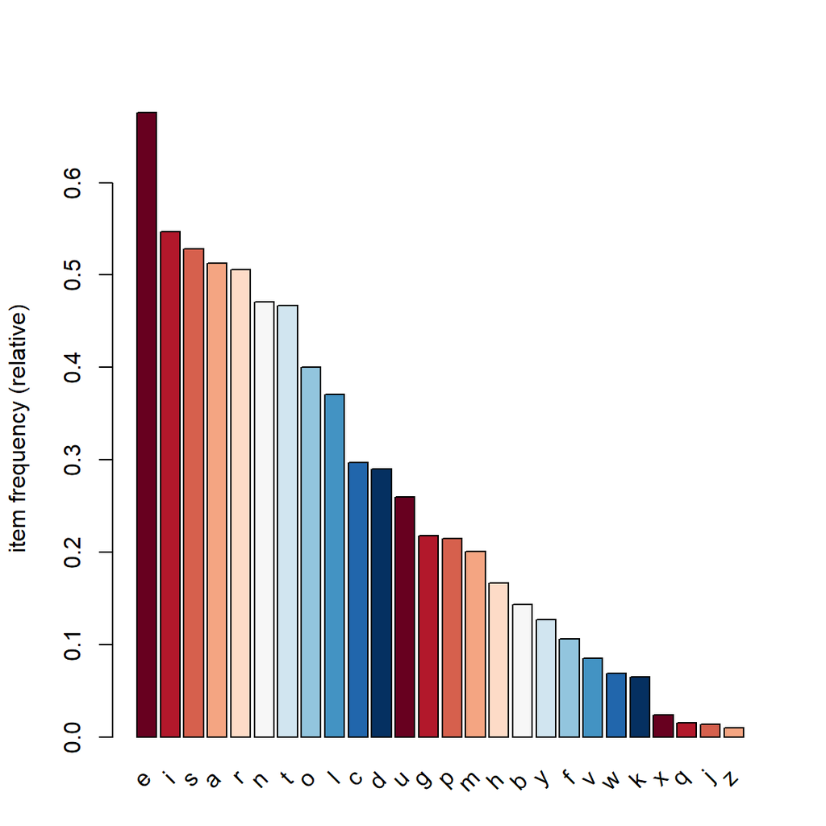

```r
itemFrequencyPlot(scrabble, topN = 26, col=brewer.pal(n = 26, name = "RdBu"))
```

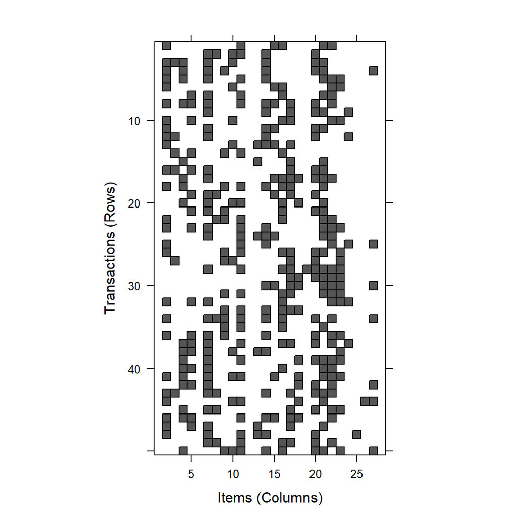

```r
#Visualisation of different letters occurances in random 50 words.
#We can see which leeter occurs in these words.
image(sample(scrabble, 50))
```

# Apriori algorithm

## What is Apriori algorithm?

Apriori is an algorithm for frequent item set mining and association rule learning over relational databases. It proceeds by identifying the frequent individual items in the database and extending them to larger and larger item sets as long as those item sets appear sufficiently often in the database. The frequent item sets determined by Apriori can be used to determine association rules which highlight general trends in the database: this has applications in domains such as market basket analysis. **

## Important rules

Association rules analysis is a technique to uncover how items are associated to each other. There are three common ways to measure association.

### 1. Support.

This says how popular an itemset is, as measured by the proportion of transactions in which an itemset appears.

If you discover that usage of given items beyond a certain proportion tend to have a significant impact on your scrabble game decision, you might consider using that proportion as your support threshold. You may then identify itemsets with support values above this threshold as significant itemsets

### 2. Confidence.

This says how likely item Y occurs in the word, when item X occurs, expressed as {X -> Y}. This is measured by the proportion for example of words with letter K, in which letter E also appears.

One drawback of the confidence measure is that it might misrepresent the importance of an association. This is because it only accounts for how popular for example letter “k” is, but not letter “e”. If K is also very popular in general, there will be a higher chance that a transaction containing apples will also contain E, thus inflating the confidence measure. To account for the base popularity of both constituent letters, we use a third measure called lift.

### 3. Lift

This says how likely letter K occurs, when letter E occurs, while controlling for how popular both letters are. A lift value greater than 1 means that letter K is likely to occur if letter E occurs, while a value less than 1 means that letter K is unlikely to occur if letter E occurs in a given word.***

```r
# Finding the association rules using the apriori algorithm for 2 letters, that occurs together at least in 20% of words, with confidence of min 50%

scrabblerules2 <- apriori(scrabble, parameter = list(support = 0.2, confidence = 0.5,  minlen = 2, maxlen=2))
```

```
## Apriori
##
## Parameter specification:
##  confidence minval smax arem  aval originalSupport maxtime support minlen
##         0.5    0.1    1 none FALSE            TRUE       5     0.2      2
##  maxlen target  ext
##       2  rules TRUE
##
## Algorithmic control:
##  filter tree heap memopt load sort verbose
##     0.1 TRUE TRUE  FALSE TRUE    2    TRUE
##
## Absolute minimum support count: 11622
##
## set item appearances ...[0 item(s)] done [0.00s].
## set transactions ...[28 item(s), 58110 transaction(s)] done [0.02s].
## sorting and recoding items ... [15 item(s)] done [0.01s].
## creating transaction tree ... done [0.04s].
## checking subsets of size 1 2
```

```
##  done [0.00s].
## writing ... [35 rule(s)] done [0.00s].
## creating S4 object  ... done [0.01s].
```

```r
summary(scrabblerules2)
```

```
## set of 35 rules
##
## rule length distribution (lhs + rhs):sizes
##  2
## 35
##
##    Min. 1st Qu.  Median    Mean 3rd Qu.    Max.
##       2       2       2       2       2       2
##
## summary of quality measures:
##     support         confidence        coverage           lift
##  Min.   :0.2032   Min.   :0.5011   Min.   :0.2897   Min.   :0.8899
##  1st Qu.:0.2453   1st Qu.:0.5253   1st Qu.:0.4337   1st Qu.:0.9759
##  Median :0.2699   Median :0.5398   Median :0.5061   Median :1.0212
##  Mean   :0.2787   Mean   :0.5773   Mean   :0.4860   Mean   :1.0358
##  3rd Qu.:0.3173   3rd Qu.:0.6226   3rd Qu.:0.5207   3rd Qu.:1.0980
##  Max.   :0.3755   Max.   :0.7897   Max.   :0.6758   Max.   :1.2336
##      count
##  Min.   :11809
##  1st Qu.:14252
##  Median :15685
##  Mean   :16198
##  3rd Qu.:18441
##  Max.   :21822
##
## mining info:
##      data ntransactions support confidence
##  scrabble         58110     0.2        0.5
```

```r
inspect(scrabblerules2[1:5])
```

```
##     lhs    rhs support   confidence coverage  lift     count
## [1] {d} => {e} 0.2287558 0.7896519  0.2896920 1.168492 13293
## [2] {l} => {a} 0.2100155 0.5668106  0.3705214 1.105503 12204
## [3] {l} => {i} 0.2124247 0.5733129  0.3705214 1.048571 12344
## [4] {l} => {e} 0.2474961 0.6679671  0.3705214 0.988428 14382
## [5] {o} => {n} 0.2032180 0.5078703  0.4001377 1.079417 11809
```

As we can see there are just 35 rules like this (some of them are doubled)

We can check simmilar rules for 3 letters

```r
# Finding the association rules using the apriori algorithm for 3 letters, that occurs together at least in 15% of words, with confidence of min 40%

scrabblerules3 <- apriori(scrabble, parameter = list(support = 0.15, confidence = 0.4,  minlen = 3, maxlen=3))
```

```
## Apriori
##
## Parameter specification:
##  confidence minval smax arem  aval originalSupport maxtime support minlen
##         0.4    0.1    1 none FALSE            TRUE       5    0.15      3
##  maxlen target  ext
##       3  rules TRUE
##
## Algorithmic control:
##  filter tree heap memopt load sort verbose
##     0.1 TRUE TRUE  FALSE TRUE    2    TRUE
##
## Absolute minimum support count: 8716
##
## set item appearances ...[0 item(s)] done [0.00s].
## set transactions ...[28 item(s), 58110 transaction(s)] done [0.03s].
## sorting and recoding items ... [16 item(s)] done [0.00s].
## creating transaction tree ... done [0.04s].
## checking subsets of size 1 2 3
```

```
##  done [0.01s].
## writing ... [60 rule(s)] done [0.00s].
## creating S4 object  ... done [0.01s].
```

```r
summary(scrabblerules3)
```

```
## set of 60 rules
##
## rule length distribution (lhs + rhs):sizes
##  3
## 60
##
##    Min. 1st Qu.  Median    Mean 3rd Qu.    Max.
##       3       3       3       3       3       3
##
## summary of quality measures:
##     support         confidence        coverage           lift
##  Min.   :0.1507   Min.   :0.4233   Min.   :0.2188   Min.   :0.8436
##  1st Qu.:0.1578   1st Qu.:0.5074   1st Qu.:0.2665   1st Qu.:0.9597
##  Median :0.1662   Median :0.5501   Median :0.3081   Median :1.0280
##  Mean   :0.1703   Mean   :0.5690   Mean   :0.3044   Mean   :1.0420
##  3rd Qu.:0.1850   3rd Qu.:0.6277   3rd Qu.:0.3295   3rd Qu.:1.1166
##  Max.   :0.1967   Max.   :0.7532   Max.   :0.3755   Max.   :1.3310
##      count
##  Min.   : 8759
##  1st Qu.: 9168
##  Median : 9657
##  Mean   : 9896
##  3rd Qu.:10749
##  Max.   :11432
##
## mining info:
##      data ntransactions support confidence
##  scrabble         58110    0.15        0.4
```

```r
inspect(scrabblerules3[1:10])
```

```
##      lhs      rhs support   confidence coverage  lift      count
## [1]  {n,t} => {i} 0.1686285 0.7277386  0.2317157 1.3310112  9799
## [2]  {i,t} => {n} 0.1686285 0.5883872  0.2865944 1.2505460  9799
## [3]  {i,n} => {t} 0.1686285 0.5313703  0.3173464 1.1371830  9799
## [4]  {n,t} => {e} 0.1565479 0.6756034  0.2317157 0.9997279  9097
## [5]  {e,t} => {n} 0.1565479 0.4856914  0.3223197 1.0322785  9097
## [6]  {e,n} => {t} 0.1565479 0.5081839  0.3080537 1.0875618  9097
## [7]  {r,t} => {e} 0.1809671 0.7446010  0.2430391 1.1018275 10516
## [8]  {e,t} => {r} 0.1809671 0.5614522  0.3223197 1.1094256 10516
## [9]  {e,r} => {t} 0.1809671 0.4818990  0.3755292 1.0313097 10516
## [10] {a,t} => {i} 0.1581655 0.6012691  0.2630528 1.0997026  9191
```

For different values of support we recieve different nr of rules: support =0,15 & confidence =0,4 -> There are 60 rules support =0,10 & confidence =0,4 -> There are 185 rules support =0,10 & confidence =0,6 -> There are 46 rules support =0,10 & confidence =0,75 -> There are 6 rules